# STAT 413/613 HW 2: stringr and lubridate

Chi Yun Liu

2021-02-18

# Instructions

Rename the starter file under the analysis directory as `hw_02_yourname.Rmd` and use it for your solutions.  
1. Modify the “author” field in the YAML header.  
2. Stage and Commit R Markdown and HTML files (no PDF files).  
3. **Push both .Rmd and HTML files to GitHub**.  
- Make sure you have knitted to HTML prior to staging, committing, and pushing your final submission.  
4. **Commit each time you answer a part of question, e.g. 1.1**  
5. **Push to GitHub after each major question**, e.g., Scrabble and Civil War Battles  
- **Committing and Pushing are graded elements for this homework.**  
6. When complete, submit a response in Canvas

- Only include necessary code to answer the questions.
- Most of the functions you use should be from the tidyverse. Too much base R will result in point deductions.
- Use Pull requests and or email to ask me any questions. If you email, please ensure your most recent code is pushed to GitHub.
- Learning objectives:
  - Manipulate dates and times with lubridate.

# 1 Scrabble Words

For this exercise, we are using the [Collins Scrabble Words](https://en.wikipedia.org/wiki/Collins_Scrabble_Words), which is most commonly used outside of the United States. The dictionary most often used in the United States is the [Tournament Word List](https://en.wikipedia.org/wiki/Official_Tournament_and_Club_Word_List).

**WARNING**: Do not try `str_view()` or `str_view_all()` on these data.It will stall your computer.

1. Use a readr function to load the 2015 list of Collins Scrabble Words into R from your data folder or from https://data-science-master.github.io/lectures/data/words.txt
   - (note: “NA” is an official Scrabble word).

```r
scwords <- read_csv(file = "../data/words.txt")
```

```
##
## ─ Column specification ────────────────────────────
```

```r
head(scwords)
```

```
## # A tibble: 6 x 1
##   word
##   <chr>
## 1 AA
## 2 AAH
## 3 AAHED
## 4 AAHING
## 5 AAHS
## 6 AAL
```

2. What are the six longest words that have the most “X”’s in them?

```r
scwords_df <- as.data.frame(scwords)
head(scwords_df)
```

```
##     word
## 1     AA
## 2    AAH
## 3  AAHED
## 4 AAHING
## 5   AAHS
## 6    AAL
```

```r
scwords_df[is.na(scwords_df)] <- "NA"

scwords_df %>%
  mutate(detect_x = str_count(word, "[Xx]")) %>%
  arrange(desc(detect_x)) %>%
  mutate(word_long = str_length(word)) %>%
  filter(detect_x == 2) %>%
  arrange(desc(word_long)) %>%
  slice_head(n = 6)
```

```
##            word detect_x word_long
## 1 COEXECUTRIXES        2        13
## 2  EXTRATEXTUAL        2        12
## 3   COEXECUTRIX        2        11
## 4   EXECUTRIXES        2        11
## 5    SAXITOXINS        2        10
## 6    XANTHOXYLS        2        10
```

```r
# COEXECUTRIXES, EXTRATEXTUAL, COEXECUTRIX, EXECUTRIXES, SAXITOXINS, XANTHOXYLS
```

3. How many words have an identical first and second half of the word? If a word has an odd number of letters, exclude the middle character.
- MURMUR counts because MUR is both the first and second half.
- JIGAJIG counts because the middle A is excluded so JIG is both the first and second half.
- Save the results to a variable.

```r
scwords_df %>%
  mutate(word_count = str_length(word)%%2) %>%
  filter(word_count == 0) %>%
  mutate(word_even = str_length(word)) %>%
  mutate(even_mid = word_even/2) %>%
  mutate(first_even = str_sub(word, 1, even_mid)) %>%
  mutate(sec_even = str_sub(word, even_mid+1, word_even)) %>%
  filter(first_even == sec_even) -> even_sum
head(even_sum)
```

```
##     word word_count word_even even_mid first_even sec_even
## 1     AA          0         2        1          A        A
## 2 AKEAKE          0         6        3        AKE      AKE
## 3   ANAN          0         4        2         AN       AN
## 4 ARAARA          0         6        3        ARA      ARA
## 5   ARAR          0         4        2         AR       AR
## 6 ATAATA          0         6        3        ATA      ATA
```

```r
scwords_df %>%
  mutate(word_count = str_length(word)%%2) %>%
  filter(word_count == 1) %>%
  mutate(word_odd = str_length(word)) %>%
  mutate(odd_mid = (word_odd + 1)/2) %>%
  mutate(first_odd = str_sub(word, 1, odd_mid-1)) %>%
  mutate(sec_odd = str_sub(word, odd_mid+1, word_odd)) %>%
  filter(first_odd == sec_odd) -> odd_sum
head(odd_sum)
```

```
##    word word_count word_odd odd_mid first_odd sec_odd
## 1   ABA          1        3       2         A       A
## 2 ADRAD          1        5       3        AD      AD
## 3   AGA          1        3       2         A       A
## 4   AHA          1        3       2         A       A
## 5   AIA          1        3       2         A       A
## 6   AKA          1        3       2         A       A
```

```r
q3_ans <- count(even_sum) + count(odd_sum)
q3_ans
```

```
##     n
## 1 254
```

```r
# 254 words have an identical first and second half of the word.
```

4. Use the results from 3 to find the longest word with an identical first and second half of the word?

```r
even_sum %>%
  arrange(desc(word_even)) %>%
  slice_head(n=1)
```

```
##           word word_count word_even even_mid first_even sec_even
## 1 CHIQUICHIQUI          0        12        6     CHIQUI   CHIQUI
```

```r
odd_sum %>%
  arrange(desc(word_odd)) %>%
  slice_head(n=1)
```

```
##        word word_count word_odd odd_mid first_odd sec_odd
## 1 EINSTEINS          1        9       5      EINS    EINS
```

```r
# CHIQUICHIQUI is the longest word with an identical first and second half of the word
```

# 2 Civil War Battles

The data in “civil_war_theater.csv” contains a information on American Civil War battles, taken from [Wikipedia](https://en.wikipedia.org/wiki/List_of_American_Civil_War_battles).

Variables include:

- `Battle`: The name of the battle.
- `Date`: The date(s) of the battle in different formats depending upon the length of the battle.
  - If it took place on one day, the format is “month day, year”.
  - If it took place over multiple days, the format is “month day_start-day_end, year”.
  - If it took place over multiple days and months, the format is “month_start day_start - month_end day_end, year”.
  - If it took place over multiple days,months, and years, the format is “month_start day_start, year_start - month_end day_end, year_end”.
- `State`: The state where the battle took place. Annotations (e.g. describing that the state was a territory at the time) are in parentheses.
- `CWSAC`: A rating of the military significance of the battle by the Civil War Sites Advisory Commission. `A` = Decisive, `B` = Major, `C` = Formative, `D` = Limited.
- `Outcome`: Usually `"Confederate victory"`, `"Union victory"`, or `"Inconclusive"`, followed by notes.
- `Theater`: An attempt to to identify which theater of war is most associated with the battle
1. Use a readr function and relative paths to load the data into R.

```r
war_df <- read_csv("../data/civil_war_theater.csv")
```

```
##
## ─ Column specification ────────────────────────────
```

```r
head(war_df)
```

```
## # A tibble: 6 x 6
##   Battle          Date      State      CWSAC Theater Outcome
##   <chr>           <chr>     <chr>      <chr> <chr>   <chr>
## 1 Battle of Fort… July 11-… District … B     Eastern Union victory: Failed Conf…
## 2 Battle of Hanc… January … Maryland   D     Eastern Inconclusive: Unsuccessful…
## 3 Battle of Sout… Septembe… Maryland   B     Eastern Union victory: McClellan d…
## 4 Battle of Anti… Septembe… Maryland   A     Eastern Tactically inconclusive; s…
## 5 Battle of Will… July 6-1… Maryland   C     Eastern Inconclusive: Meade and Le…
## 6 Battle of Boon… July 8, … Maryland   D     Eastern Inconclusive: Indecisive a…
```

The next several questions will help you take the dates from all the different formats and create a consistent set of start date and end date variables in the data frame. We will start by calculating how many years, and months are in each battle.

2. Add a variable to the data frame with the number of years for each battle.
- Create a character variable as follows. This can be used as a pattern in a regular expression.
- Use `year_regex` to now count the number of years in each battle, add this to the data frame, and save the data frame.

```r
year_regex <- stringr::str_c(1861:1865, collapse = "|")
year_regex
```

```
## [1] "1861|1862|1863|1864|1865"
```

```r
war_df %>%
  mutate(num_years = str_count(Date, year_regex)) %>%
  select(Battle, Date, num_years, everything())->war_df
head(war_df)
```

```
## # A tibble: 6 x 7
##   Battle        Date     num_years State    CWSAC Theater Outcome
##   <chr>         <chr>        <int> <chr>    <chr> <chr>   <chr>
## 1 Battle of Fo… July 11…         1 Distric… B     Eastern Union victory: Failed…
## 2 Battle of Ha… January…         1 Maryland D     Eastern Inconclusive: Unsucce…
## 3 Battle of So… Septemb…         1 Maryland B     Eastern Union victory: McClel…
## 4 Battle of An… Septemb…         1 Maryland A     Eastern Tactically inconclusi…
## 5 Battle of Wi… July 6-…         1 Maryland C     Eastern Inconclusive: Meade a…
## 6 Battle of Bo… July 8,…         1 Maryland D     Eastern Inconclusive: Indecis…
```

3. Add a variable to the data frame with the number of months for each battle.
- Consider R’s built-in vector of month names: `month.name`.
- Use `month.name` to count the number of month names in the `Date` variable in each battle.
- Add this to the data frame. (You might need to do something similar to what we did in part 2).

```r
month_regex <- stringr::str_c(month.name, collapse = "|")
month_regex
```

```
## [1] "January|February|March|April|May|June|July|August|September|October|November|December"
```

```r
war_df %>%
  mutate(num_month = str_count(Date, month_regex)) %>%
  select(Battle, Date, num_month, everything())->war_df
head(war_df)
```

```
## # A tibble: 6 x 8
##   Battle      Date    num_month num_years State   CWSAC Theater Outcome
##   <chr>       <chr>       <int>     <int> <chr>   <chr> <chr>   <chr>
## 1 Battle of … July 1…         1         1 Distri… B     Eastern Union victory: …
## 2 Battle of … Januar…         1         1 Maryla… D     Eastern Inconclusive: U…
## 3 Battle of … Septem…         1         1 Maryla… B     Eastern Union victory: …
## 4 Battle of … Septem…         1         1 Maryla… A     Eastern Tactically inco…
## 5 Battle of … July 6…         1         1 Maryla… C     Eastern Inconclusive: M…
## 6 Battle of … July 8…         1         1 Maryla… D     Eastern Inconclusive: I…
```

4. Add a variable to the data frame that is `TRUE` if `Date` spans multiple days and is `FALSE` otherwise. Spanning multiple months and/or years also counts as `TRUE`.

```r
war_df %>%
  mutate(dmulti_span = str_detect(Date, "-")) %>%
  select(Battle, Date,dmulti_span, num_month, everything())->war_df
head(war_df)
```

```
## # A tibble: 6 x 9
##   Battle   Date   dmulti_span num_month num_years State CWSAC Theater Outcome
##   <chr>    <chr>  <lgl>           <int>     <int> <chr> <chr> <chr>   <chr>
## 1 Battle … July … TRUE                1         1 Dist… B     Eastern Union vic…
## 2 Battle … Janua… TRUE                1         1 Mary… D     Eastern Inconclus…
## 3 Battle … Septe… FALSE               1         1 Mary… B     Eastern Union vic…
## 4 Battle … Septe… FALSE               1         1 Mary… A     Eastern Tacticall…
## 5 Battle … July … TRUE                1         1 Mary… C     Eastern Inconclus…
## 6 Battle … July … FALSE               1         1 Mary… D     Eastern Inconclus…
```

5. Make four new data frames by filtering the data based on the length of the battles:
   - a data frame with the data for only those battles spanning just one day,

```r
war_df %>%
  filter(dmulti_span == FALSE) -> one_day
head(one_day)
```

```
## # A tibble: 6 x 9
##   Battle   Date   dmulti_span num_month num_years State CWSAC Theater Outcome
##   <chr>    <chr>  <lgl>           <int>     <int> <chr> <chr> <chr>   <chr>
## 1 Battle … Septe… FALSE               1         1 Mary… B     Eastern Union vic…
## 2 Battle … Septe… FALSE               1         1 Mary… A     Eastern Tacticall…
## 3 Battle … July … FALSE               1         1 Mary… D     Eastern Inconclus…
## 4 Battle … July … FALSE               1         1 Mary… B     Eastern Confedera…
## 5 Battle … Augus… FALSE               1         1 Mary… D     Eastern Inconclus…
## 6 Battle … June … FALSE               1         1 Penn… C     Eastern Inconclus…
```

- a data frame with the data for only those battles spanning multiple days in just one month,

```r
war_df %>%
  filter(num_month == 1 & dmulti_span == TRUE) ->one_mon
head(one_mon)
```

```
## # A tibble: 6 x 9
##   Battle  Date   dmulti_span num_month num_years State  CWSAC Theater Outcome
##   <chr>   <chr>  <lgl>           <int>     <int> <chr>  <chr> <chr>   <chr>
## 1 Battle… July … TRUE                1         1 Distr… B     Eastern Union vic…
## 2 Battle… Janua… TRUE                1         1 Maryl… D     Eastern Inconclus…
## 3 Battle… July … TRUE                1         1 Maryl… C     Eastern Inconclus…
## 4 Battle… July … TRUE                1         1 Penns… A     Eastern Union vic…
## 5 Battle… May 1… TRUE                1         1 Virgi… D     Eastern Inconclus…
## 6 Battle… March… TRUE                1         1 Virgi… B     Eastern Inconclus…
```

- a data frame with the data for only those battles spanning multiple months but not multiple years, and,

```r
war_df %>%
  filter(num_month > 1 & num_years <2)->multi_mon
head(multi_mon)
```

```
## # A tibble: 6 x 9
##   Battle    Date  dmulti_span num_month num_years State CWSAC Theater Outcome
##   <chr>     <chr> <lgl>           <int>     <int> <chr> <chr> <chr>   <chr>
## 1 Battle o… May … TRUE                2         1 Virg… D     Eastern Inconclus…
## 2 Siege of… Apri… TRUE                2         1 Virg… B     Eastern Inconclus…
## 3 Battle o… May … TRUE                2         1 Virg… B     Eastern Inconclus…
## 4 Battle o… Apri… TRUE                2         1 Virg… C     Eastern Inconclus…
## 5 Battle o… Apri… TRUE                2         1 Virg… C     Eastern Inconclus…
## 6 Battle o… Apri… TRUE                2         1 Virg… A     Eastern Confedera…
```

- a data frame with the data for only those battles spanning multiple years.

```r
war_df %>%
  filter(num_years > 1)->multi_years
head(multi_years)
```

```
## # A tibble: 1 x 9
##   Battle    Date   dmulti_span num_month num_years State CWSAC Theater Outcome
##   <chr>     <chr>  <lgl>           <int>     <int> <chr> <chr> <chr>   <chr>
## 1 Battle o… Decem… TRUE                2         2 Tenn… A     Western Union vi…
```

6. For each of the four new data frames,
- Add two new variables:
  - `Start` should contain the start-date of each battle.
  - `End` should contain the end-date of each battle.
  - Hint: look at help for `separate()`
  - Make sure these are `Date` class objects.
- Remove the `Date` variable from each data frame.
- Save the data frames with the new variables

```r
one_day %>%
  mutate(Start = parse_date(Date, format = "%B %d, %Y")) %>%
  mutate(End = parse_date(Date, format = "%B %d, %Y")) %>%
  select(Battle, Start, End, everything(), -Date)->
  one_day
head(one_day)
```

```
## # A tibble: 6 x 10
##   Battle Start      End        dmulti_span num_month num_years State CWSAC
##   <chr>  <date>     <date>     <lgl>           <int>     <int> <chr> <chr>
## 1 Battl… 1862-09-14 1862-09-14 FALSE               1         1 Mary… B
## 2 Battl… 1862-09-17 1862-09-17 FALSE               1         1 Mary… A
## 3 Battl… 1863-07-08 1863-07-08 FALSE               1         1 Mary… D
## 4 Battl… 1864-07-09 1864-07-09 FALSE               1         1 Mary… B
## 5 Battl… 1864-08-01 1864-08-01 FALSE               1         1 Mary… D
## 6 Battl… 1863-06-30 1863-06-30 FALSE               1         1 Penn… C
## # … with 2 more variables: Theater <chr>, Outcome <chr>
```

```r
one_mon %>%
  separate(Date, into = c("Month", "Year"), sep = ",") %>%
  separate(Month, into = c("Month", "Sday"), sep = " ") %>%
  separate(Sday, into = c("Sday", "Eday"), sep = "-") %>%
  mutate(Day_span = as.double(Eday) - as.double(Sday)) %>%
  unite(Start, Month, Sday, Year, sep = "-") %>%
  mutate(Start = parse_date(Start, format = "%B-%d- %Y")) %>%
  mutate(End = Start + Day_span) %>%
  select(Battle,Start, End, everything(), -Eday, -Day_span)-> one_mon
head(one_mon)
```

```
## # A tibble: 6 x 10
##   Battle Start      End        dmulti_span num_month num_years State CWSAC
##   <chr>  <date>     <date>     <lgl>           <int>     <int> <chr> <chr>
## 1 Battl… 1864-07-11 1864-07-12 TRUE                1         1 Dist… B
## 2 Battl… 1862-01-05 1862-01-06 TRUE                1         1 Mary… D
## 3 Battl… 1863-07-06 1863-07-16 TRUE                1         1 Mary… C
## 4 Battl… 1863-07-01 1863-07-03 TRUE                1         1 Penn… A
## 5 Battl… 1861-05-18 1861-05-19 TRUE                1         1 Virg… D
## 6 Battl… 1862-03-08 1862-03-09 TRUE                1         1 Virg… B
## # … with 2 more variables: Theater <chr>, Outcome <chr>
```

```r
multi_mon %>%
  separate(Date, into = c("dspan", "Year"), sep = ",") %>%
  separate(dspan, into = c("Sdate", "Edate"), sep = "-" ) %>%
  mutate(new_sdate = str_trim(Sdate)) %>%
  mutate(year_1 = Year) %>%
  unite(new_sdate, Year, col = "SSdate", sep = ",") %>%
  unite(Edate, year_1, col = "EEdate", sep = ",") %>%
  mutate(Start = parse_date(SSdate, format = "%B %d, %Y")) %>%
  mutate(End = parse_date(EEdate, format = "%B %d, %Y")) %>%
  select(Battle, Start, End, everything(), -Sdate, -EEdate, -SSdate,)->multi_mon
head(multi_mon)
```

```
## # A tibble: 6 x 10
##   Battle Start      End        dmulti_span num_month num_years State CWSAC
##   <chr>  <date>     <date>     <lgl>           <int>     <int> <chr> <chr>
## 1 Battl… 1861-05-29 1861-06-01 TRUE                2         1 Virg… D
## 2 Siege… 1862-04-05 1862-05-04 TRUE                2         1 Virg… B
## 3 Battl… 1862-05-31 1862-06-01 TRUE                2         1 Virg… B
## 4 Battl… 1863-04-11 1863-05-04 TRUE                2         1 Virg… C
## 5 Battl… 1863-04-11 1863-05-04 TRUE                2         1 Virg… C
## 6 Battl… 1863-04-30 1863-05-06 TRUE                2         1 Virg… A
## # … with 2 more variables: Theater <chr>, Outcome <chr>
```

```r
multi_years %>%
  separate(Date, into = c("Start", "End"), sep = "-") %>%
  mutate(new_start = str_trim(Start)) %>%
  mutate(Start = parse_date(new_start, format = "%B %d, %Y")) %>%
  mutate(End = parse_date(End, format = "%B %d, %Y")) %>%
  select(Battle, Start, End, everything(), -new_start)->multi_years
head(multi_years)
```

```
## # A tibble: 1 x 10
##   Battle Start      End        dmulti_span num_month num_years State CWSAC
##   <chr>  <date>     <date>     <lgl>           <int>     <int> <chr> <chr>
## 1 Battl… 1862-12-31 1863-01-02 TRUE                2         2 Tenn… A
## # … with 2 more variables: Theater <chr>, Outcome <chr>
```

7. Create a new data frame with all the battles and the Start and End dates by binding the rows of the four data frames as updated in part 6

```r
civil_war <- bind_rows(list(one_day, one_mon, multi_mon, multi_years))
head(civil_war)
```

```
## # A tibble: 6 x 10
##   Battle Start      End        dmulti_span num_month num_years State CWSAC
##   <chr>  <date>     <date>     <lgl>           <int>     <int> <chr> <chr>
## 1 Battl… 1862-09-14 1862-09-14 FALSE               1         1 Mary… B
## 2 Battl… 1862-09-17 1862-09-17 FALSE               1         1 Mary… A
## 3 Battl… 1863-07-08 1863-07-08 FALSE               1         1 Mary… D
## 4 Battl… 1864-07-09 1864-07-09 FALSE               1         1 Mary… B
## 5 Battl… 1864-08-01 1864-08-01 FALSE               1         1 Mary… D
## 6 Battl… 1863-06-30 1863-06-30 FALSE               1         1 Penn… C
## # … with 2 more variables: Theater <chr>, Outcome <chr>
```

8. Calculate the number of days each battle spanned.
- What’s the longest battle of the war?
- How long did it last?

```r
civil_war %>%
  mutate(Span = End - Start) %>%
  select(Battle, Start, End, Span, everything()) %>%
  arrange(desc(Span)) %>%
  slice_head(n = 1)
```

```
## # A tibble: 1 x 11
##   Battle Start      End        Span  dmulti_span num_month num_years State CWSAC
##   <chr>  <date>     <date>     <drt> <lgl>           <int>     <int> <chr> <chr>
## 1 Siege… 1863-05-21 1863-07-09 49 d… TRUE                2         1 Loui… A
## # … with 2 more variables: Theater <chr>, Outcome <chr>
```

```r
# Siege of Port Hudson is the longest battle, and it last 49 days long.
```

9. Is there an association between the CWSAC significance of a battle and its duration?
- Create an appropriate plot.
- Interpret the plot in one sentence to answer the question.
- Extra Credit: Test for a linear relationship using `lm()` and interpret the results in one sentence based on the $p$-value and adjusted R-squared.

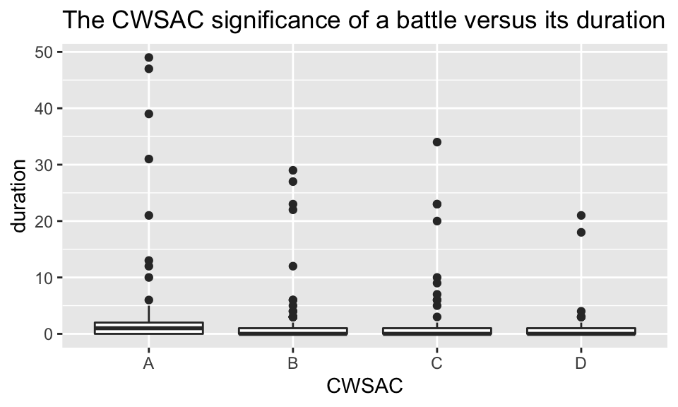

```r
war_dur <- civil_war$End - civil_war$Start

civil_war %>%
  ggplot(mapping = aes(x = CWSAC, y = (war_dur))) +
  geom_boxplot() +
  labs(title = "The CWSAC significance of a battle versus its duration",
       y = "duration")
```

```r
# The boxplot shows that the level of A is more spread in duration with higher median, but overall CWSAC significance of a battle are generally similar in its duration that spreading around 0-3 days.
```

```r
lm_model <- lm(as.double(war_dur) ~ as.factor(CWSAC), data = civil_war)
summary(lm_model)
```

```
##
## Call:
## lm(formula = as.double(war_dur) ~ as.factor(CWSAC), data = civil_war)
##
## Residuals:
##    Min     1Q Median     3Q    Max
## -5.778 -1.808 -0.808 -0.680 43.222
##
## Coefficients:
##                   Estimate Std. Error t value Pr(>|t|)
## (Intercept)         5.7778     0.8625   6.699 7.60e-11 ***
## as.factor(CWSAC)B  -3.9701     1.0324  -3.845 0.000141 ***
## as.factor(CWSAC)C  -4.3920     1.0038  -4.375 1.57e-05 ***
## as.factor(CWSAC)D  -4.9907     1.0266  -4.861 1.71e-06 ***
## ---
## Signif. codes:  0 '***' 0.001 '**' 0.01 '*' 0.05 '.' 0.1 ' ' 1
##
## Residual standard error: 5.786 on 380 degrees of freedom
## Multiple R-squared:  0.0622, Adjusted R-squared:  0.0548
## F-statistic: 8.401 on 3 and 380 DF,  p-value: 2.026e-05
```

```r
# The model is significant since the p-value is extremely small(2.026e-05<.05), but only 5.48% of the variability is explained by the model.
```

10. Extra Credit: Did the theaters of war shift during the American Civil War?
- Reproduce this plot in R (filter out states with two or fewer battles.)
- Interpret the plot in one sentence.

```r
# Combine state with the same name (rename input)
# filter n > 2
# deal with plot: state names
# plot

# rename input
civil_war %>%
  mutate(State = str_replace_all(State, "West Virginia \\(Virginia at the time\\)", "West Virginia")) %>%
  mutate(State = str_replace_all(State, "North Dakota \\(Dakota Territory at the time\\)", "North Dakota")) %>%
  mutate(State = str_replace_all(State, "North Dakota \\(Dakota Territory..............", "North Dakota")) %>%
  mutate(State = str_replace_all(State, "Oklahoma \\(Indian Territory at the time\\)", "Oklahoma")) -> civil_war01

unique(civil_war01$State)
```

```
##  [1] "Maryland"
##  [2] "Pennsylvania"
##  [3] "Virginia"
##  [4] "West Virginia"
##  [5] "Florida"
##  [6] "Louisiana"
##  [7] "Mississippi"
##  [8] "North Carolina"
##  [9] "South Carolina"
## [10] "Texas"
## [11] "Arkansas"
## [12] "Indiana"
## [13] "Kansas"
## [14] "Minnesota"
## [15] "Missouri"
## [16] "Ohio"
## [17] "Alabama"
## [18] "Colorado (Colorado Territory at the time)"
## [19] "Georgia"
## [20] "Idaho (Washington Territory at the time)"
## [21] "Kentucky"
## [22] "North Dakota"
## [23] "Oklahoma"
## [24] "Tennessee"
## [25] "District of Columbia"
## [26] "New Mexico (New Mexico Territory at the time)"
```

```r
#civil_war01 %>%
  #filter(State == "West Virginia")

# filter n <= 2
civil_war01 %>%
  group_by(State) %>%
  count() %>%
  filter(n <= 2) -> civil_war02

civil_war01 %>%
  anti_join(civil_war02, by = "State") %>%
  mutate(Theater_new = Theater) %>%
  unite(State, Theater_new, col = "state_thr", sep = "-") %>%
  select(Battle, state_thr, Start, Theater) -> civil_war01

civil_war01 %>%
  #filter(Theater == "Lower Seaboard" | Theater == "Western") %>%
  group_by(state_thr) %>%
  #count() %>%
  mutate(state_thr = str_replace_all(state_thr, "Lower Seaboard", "Lo")) %>%
  mutate(state_thr = str_replace_all(state_thr, "Western", "We")) %>%
  mutate(state_thr = str_replace_all(state_thr, "\\-Eastern", "")) %>%
  mutate(state_thr = str_replace_all(state_thr, "\\-Trans-Mississippi", "")) %>%
  mutate(state_thr = as.factor(state_thr))->civil_war01

unique(civil_war01$state_thr)
```

```
##  [1] Maryland          Virginia          West Virginia     Florida-Lo
##  [5] Louisiana-Lo      Mississippi-Lo    North Carolina-Lo South Carolina-Lo
##  [9] Texas-Lo          Arkansas          Kansas            Missouri
## [13] Alabama-We        Florida-We        Georgia-We        Kentucky-We
## [17] Louisiana-We      Mississippi-We    North Carolina-We North Dakota-We
## [21] Oklahoma-We       South Carolina-We Tennessee-We      Texas-We
## [25] Alabama-Lo
## 25 Levels: Alabama-Lo Alabama-We Arkansas Florida-Lo Florida-We ... West Virginia
```

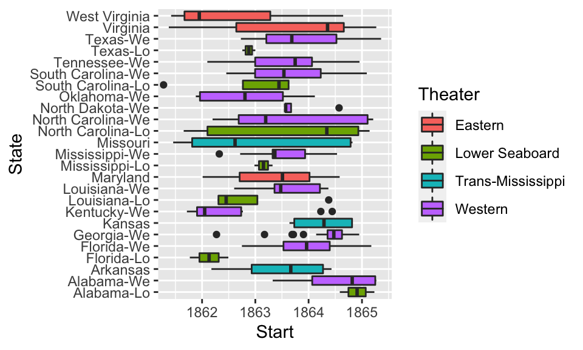

```r
civil_war01 %>%
  ggplot(mapping = aes(x = Start, y = state_thr, fill =Theater)) +
  geom_boxplot()+
  labs(x = "Start", y = "State")
```

- The trend of purple bar in the plot shows that the theater did shift to the western and most of the theater are also in the western.